# PETER GRIMES - Bayerische Staatsoper

[figure not shown]

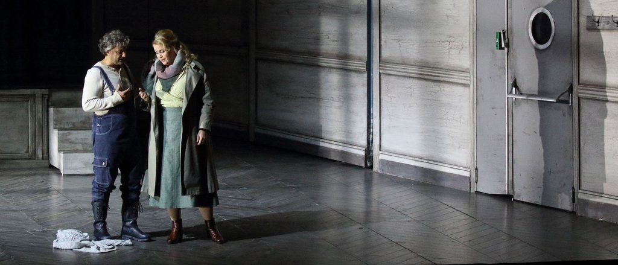

# PETER GRIMES

empfohlen ab 14 Jahren  
Oper in drei Akten und einem Prolog von Benjamin Britten (1945)

Komponist Benjamin Britten. Text von Montagu Slater nach dem Gedicht von George Crabbe.  
In englischer Sprache · Mit Übertiteln in deutscher und englischer Sprache. Neuproduktion.

Sonntag, 06. März 2022, 18.00 Uhr, Nationaltheater.

**1. Akt** (ca. 18.00 - 19.00 Uhr) Pause (ca. 19.00 - 19.30 Uhr) **2. + 3. Akt** (ca. 19.30 - 21.00 Uhr)

Abo-Serie 26

[Termin merken](https://www.staatsoper.de/stuecke/peter-grimes/2022-03-06-1800-12801/calendar.ics)

[figure not shown]

| Musikalische Leitung | [Edward Gardner](https://www.staatsoper.de/biographien/gardner-edward) |
| --- | --- |
| Inszenierung | [Stefan Herheim](https://www.staatsoper.de/biographien/herheim-stefan) |
| Bühne | [Silke Bauer](https://www.staatsoper.de/biographien/bauer-silke) |
| Kostüme | [Esther Bialas](https://www.staatsoper.de/biographien/bialas-esther) |
| Licht | [Michael Bauer](https://www.staatsoper.de/biographien/bauer-michael) |
| Video | [Torge Møller](https://www.staatsoper.de/biographien/moeller-torge) |
| Produktionsdramaturgie | [Malte Krasting](https://www.staatsoper.de/biographien/krasting-malte) [Alexander Meier-Dörzenbach](https://www.staatsoper.de/biographien/meier-doerzenbach-alexander) |
| Chor | [Stellario Fagone](https://www.staatsoper.de/biographien/fagone-stellario) |

| Peter Grimes | [Stuart Skelton](https://www.staatsoper.de/biographien/skelton-stuart) |
| --- | --- |
| Ellen Orford | [Rachel Willis-Sørensen](https://www.staatsoper.de/biographien/willis-soerensen-rachel) |
| Balstrode | [Iain Paterson](https://www.staatsoper.de/biographien/paterson-iain) |
| Auntie | [Claudia Mahnke](https://www.staatsoper.de/biographien/mahnke-claudia) |
| 1. Nichte | [Lindsay Ohse](https://www.staatsoper.de/biographien/ohse-lindsay) |
| Swallow | [Brindley Sherratt](https://www.staatsoper.de/biographien/sherratt-brindley) |
| Mrs. Sedley | [Jennifer Johnston](https://www.staatsoper.de/biographien/johnston-jennifer) |
| Rev. Horace Adams | [Robert Murray](https://www.staatsoper.de/biographien/murray-robert) |
| 2. Nichte | [Emily Pogorelc](https://www.staatsoper.de/biographien/pogorelc-emily) |
| Bob Boles | [Thomas Ebenstein](https://www.staatsoper.de/biographien/ebenstein-thomas) |
| Ned Keene | [Konstantin Krimmel](https://www.staatsoper.de/biographien/krimmel-konstantin) |
| Hobson | [Daniel Noyola](https://www.staatsoper.de/biographien/noyola-daniel) |
| Der Junge | [Jakob Biber](https://www.staatsoper.de/biographien/biber-jakob) |

| Bayerisches Staatsorchester |
| --- |
| Bayerischer Staatsopernchor |

[Download Besetzungszettel (PDF)](https://www.staatsoper.de/media/content/PDF/Besetzungszettel_21_22/KW9/Peter_Grimes_22_03_06__I.pdf)

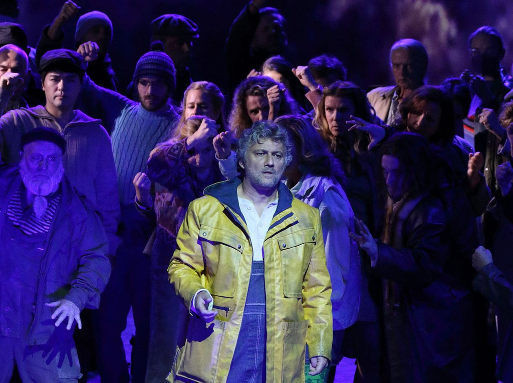

PETER GRIMES 2022 J. Kaufmann © W.Hösl

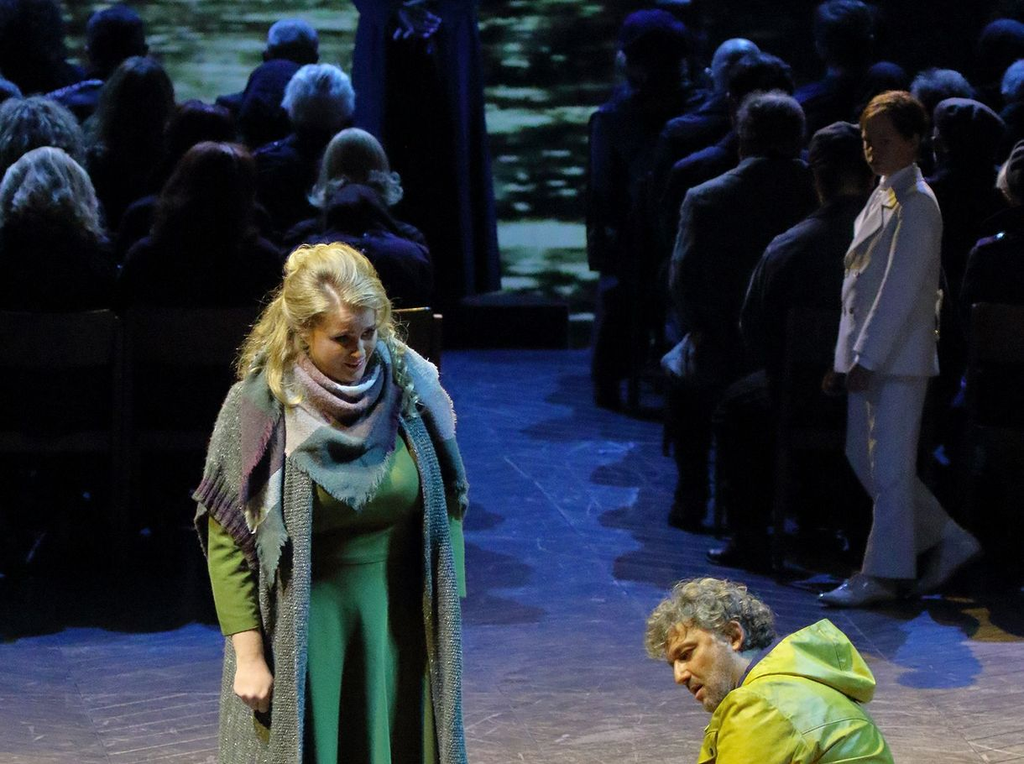

PETER GRIMES 2022 R.Willis-Soerensen © W.Hösl

[figure not shown]

PETER GRIMES 2022 © W.Hösl

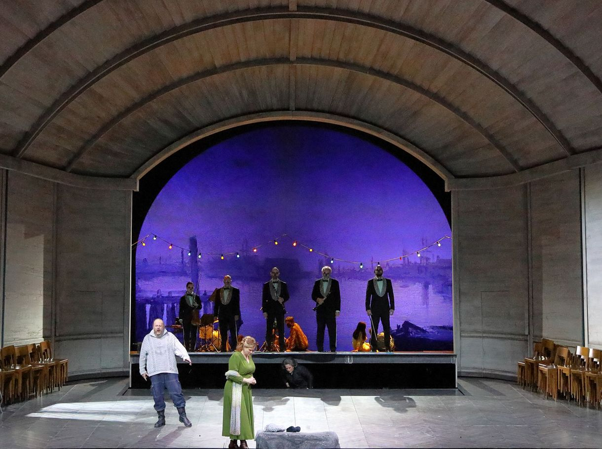

PETER GRIMES 2022 I.Paterson R.Willis-Soerensen J.Johnston © W.Hösl

[video not shown]

[video not shown]

## Vergangene Vorstellungen

Fr 30.09.22

## PETER GRIMES

Benjamin Britten  
19.00 Uhr, Nationaltheater

Oper

Di 27.09.22

## PETER GRIMES

Benjamin Britten  
19.00 Uhr, Nationaltheater

Oper

Sa 24.09.22

## PETER GRIMES

Benjamin Britten  
19.00 Uhr, Nationaltheater

Oper

Mi 21.09.22

## PETER GRIMES

Benjamin Britten  
19.00 Uhr, Nationaltheater

Oper

Di 12.07.22

## PETER GRIMES

Benjamin Britten  
19.00 Uhr, Nationaltheater

Oper

Sa 09.07.22

## PETER GRIMES

Benjamin Britten  
19.00 Uhr, Nationaltheater

Oper

So 13.03.22

## PETER GRIMES

Benjamin Britten  
19.00 Uhr, Nationaltheater

Oper

Do 10.03.22

## PETER GRIMES

Benjamin Britten  
19.00 Uhr, Nationaltheater

Oper

So 06.03.22

## PETER GRIMES

Benjamin Britten  
18.00 Uhr, Nationaltheater

Oper

Do 03.03.22

## ABGESAGT: Peter Grimes

Benjamin Britten  
19.00 Uhr, Nationaltheater

Oper

Mo 28.02.22

## ABGESAGT: Peter Grimes

Benjamin Britten  
19.00 Uhr, Nationaltheater

Oper

So 27.02.22

## Einführungsmatinee: Peter Grimes

Benjamin Britten  
11.00 Uhr, Nationaltheater

Oper

So 20.02.22

## PETER GRIMES

Benjamin Britten  
11.00 Uhr, Nationaltheater

Oper

Mi 07.12.22

## LOHENGRIN

Richard Wagner  
18.00 Uhr, Nationaltheater  
Abo-Serie 45

Preise O , € 218 /190 /- /130 /- /- /- /15

Oper

[Tickets](https://tickets.staatstheater.bayern/bso.webshop/webticket/shop?language=de&event=34957)

[Termin merken](https://www.staatsoper.de/stuecke/lohengrin/2022-12-07-1800-13240/calendar.ics)

Fr 09.12.22

## SPRING DOCH

Gordon Kampe  
14.00 Uhr, Rennert-Saal  
PREMIERE!

Preise PG20 , € 20

KIND&CO

[Tickets](https://tickets.staatstheater.bayern/bso.webshop/webticket/shop?language=de&event=35234)

[Termin merken](https://www.staatsoper.de/stuecke/spring-doch/2022-12-09-1400-13491/calendar.ics)

Fr 09.12.22

## Kindereinführung - HÄNSEL UND GRETEL

17.15 Uhr, Königssaal im Nationaltheater

Preise PG3

KIND&CO

Fr 09.12.22

## HÄNSEL UND GRETEL

Engelbert Humperdinck  
18.00 Uhr, Nationaltheater  
<30, Familienvorstellung

Preise I , € 100 /88 /73 /56 /40 /25 /12 /9

Oper

[Tickets](https://tickets.staatstheater.bayern/bso.webshop/webticket/shop?language=de&event=34898)

[Termin merken](https://www.staatsoper.de/stuecke/haensel-und-gretel/2022-12-09-1800-13241/calendar.ics)

Sa 10.12.22

## Kindereinführung - HÄNSEL UND GRETEL

10.15 Uhr, Königssaal im Nationaltheater

Preise PG3

KIND&CO

ausverkauftausverk.

Sa 10.12.22

## HÄNSEL UND GRETEL

Engelbert Humperdinck  
11.00 Uhr, Nationaltheater  
Familienvorstellung

Preise H , € 88 /77 /63 /50 /35 /23 /11 /8

Oper

[Tickets](https://tickets.staatstheater.bayern/bso.webshop/webticket/shop?language=de&event=34900)

[Termin merken](https://www.staatsoper.de/stuecke/haensel-und-gretel/2022-12-10-1100-13242/calendar.ics)

Sa 10.12.22

## Kindereinführung - HÄNSEL UND GRETEL

17.15 Uhr, Königssaal im Nationaltheater

Preise PG3

KIND&CO

ausverkauftausverk.

Sa 10.12.22

## HÄNSEL UND GRETEL

Engelbert Humperdinck  
18.00 Uhr, Nationaltheater  
Familienvorstellung, <30

Preise I , € 100 /88 /73 /56 /40 /25 /12 /9

Oper

[Tickets](https://tickets.staatstheater.bayern/bso.webshop/webticket/shop?language=de&event=34899)

[Termin merken](https://www.staatsoper.de/stuecke/haensel-und-gretel/2022-12-10-1800-13243/calendar.ics)

Sa 10.12.22

## Advents-Benefizkonzert

19.00 Uhr, Cuvilliés-Theater

Konzert

[Tickets](https://abk.bmw-veranstaltung.de/ticketbestellung)

Sa 10.12.22

## Weihnachten mit OperaBrass: A WINTER'S TALE

20.00 Uhr, St. Michael  
<30

Preise PG20 , € 20 /15

Konzert

[Tickets](https://tickets.staatstheater.bayern/bso.webshop/webticket/shop?language=de&event=35035)

[Termin merken](https://www.staatsoper.de/stuecke/weihnachten-mit-operabrass/2022-12-10-2000-13594/calendar.ics)

So 11.12.22

## SPRING DOCH

Gordon Kampe  
11.00 Uhr, Rennert-Saal

Preise PG20

KIND&CO

ausverkauftausverk.

So 11.12.22

## LOHENGRIN

Richard Wagner  
17.00 Uhr, Nationaltheater  
Abo-Serie 11

Preise M , € - /- /- /- /- /- /- /14

Oper

[Tickets](https://tickets.staatstheater.bayern/bso.webshop/webticket/shop?language=de&event=34958)

[Termin merken](https://www.staatsoper.de/stuecke/lohengrin/2022-12-11-1700-13244/calendar.ics)

So 11.12.22

## Porträtkonzert des Opernstudios

18.00 Uhr, Künstlerhaus  
<30

Preise PG20 , € 20

Konzert

[Tickets](https://tickets.staatstheater.bayern/bso.webshop/webticket/shop?language=de&event=35040)

[Termin merken](https://www.staatsoper.de/stuecke/portraetkonzert-des-opernstudios/2022-12-11-1800-13245/calendar.ics)

Mo 12.12.22

## SPRING DOCH

Gordon Kampe  
11.00 Uhr, Rennert-Saal  
SCHULE&CO

Preise PG20

KIND&CO

ausverkauftausverk.

Mo 12.12.22

## HÄNSEL UND GRETEL

Engelbert Humperdinck  
19.00 Uhr, Nationaltheater  
Abo-Serie 21, <30

Preise I , € 100 /88 /73 /56 /40 /25 /12 /9

Oper

[Tickets](https://tickets.staatstheater.bayern/bso.webshop/webticket/shop?language=de&event=34901)

[Termin merken](https://www.staatsoper.de/stuecke/haensel-und-gretel/2022-12-12-1900-13246/calendar.ics)

Di 13.12.22

## SPRING DOCH

Gordon Kampe  
11.00 Uhr, Rennert-Saal  
SCHULE&CO

Preise PG20

KIND&CO

ausverkauftausverk.

Di 13.12.22

## SPRING DOCH

Gordon Kampe  
17.00 Uhr, Rennert-Saal

Preise PG20 , € 20

KIND&CO

[Tickets](https://tickets.staatstheater.bayern/bso.webshop/webticket/shop?language=de&event=35238)

[Termin merken](https://www.staatsoper.de/stuecke/spring-doch/2022-12-13-1700-13495/calendar.ics)

Mi 14.12.22

## LOHENGRIN

Richard Wagner  
18.00 Uhr, Nationaltheater  
Abo-Serie 52

Preise M , € - /- /- /- /- /- /- /14

Oper

[Tickets](https://tickets.staatstheater.bayern/bso.webshop/webticket/shop?language=de&event=34959)

[Termin merken](https://www.staatsoper.de/stuecke/lohengrin/2022-12-14-1800-13247/calendar.ics)

Mi 14.12.22

## BEYOND HOLY NIGHT: Weihnachtskonzert

20.00 Uhr, Brainlab  
<30

Preise PG20 , € 20

Konzert

[Tickets](https://tickets.staatstheater.bayern/bso.webshop/webticket/shop?language=de&event=36257)

[Termin merken](https://www.staatsoper.de/stuecke/weihnachtskonzert-beyond-holy-night/2022-12-14-2000-13840/calendar.ics)

Do 15.12.22

## SPRING DOCH

Gordon Kampe  
11.00 Uhr, Rennert-Saal  
SCHULE&CO

Preise PG20

KIND&CO

ausverkauftausverk.

Fr 16.12.22

## SPRING DOCH

Gordon Kampe  
15.00 Uhr, Rennert-Saal

Preise PG20

KIND&CO

ausverkauftausverk.

Sa 17.12.22

## LOHENGRIN

Richard Wagner  
17.00 Uhr, Nationaltheater  
Abo-Serie 61

Preise M , € - /- /- /- /- /- /- /14

Oper

[Tickets](https://tickets.staatstheater.bayern/bso.webshop/webticket/shop?language=de&event=34960)

[Termin merken](https://www.staatsoper.de/stuecke/lohengrin/2022-12-17-1700-13248/calendar.ics)

So 18.12.22

## EINFÜHRUNGSMATINEE ZU TSCHAIKOWSKI-OUVERTÜREN

11.00 Uhr, Nationaltheater

Preise PG10 , € 10

Ballett

[Tickets](https://tickets.staatstheater.bayern/bso.webshop/webticket/shop?language=de&event=34989)

[Termin merken](https://www.staatsoper.de/stuecke/einfuehrungsmatinee-zu-tschaikowski-ouvertueren/18-12-2022-1100-13601/calendar.ics)

So 18.12.22

## AUSVERKAUFT: Einführungsworkshop - CINDERELLA

14.00 Uhr, Ballett-Probenhaus Platzl 7  
Einführungsworkshops

KIND&CO

[Tickets](https://staatsoper.de/service/karten-spieloper/spielballett)

So 18.12.22

## Kindereinführung - HÄNSEL UND GRETEL

16.15 Uhr, Königssaal im Nationaltheater

Preise PG3

KIND&CO

ausverkauftausverk.

So 18.12.22

## HÄNSEL UND GRETEL

Engelbert Humperdinck  
17.00 Uhr, Nationaltheater  
Familienvorstellung

Preise I , € 100 /88 /73 /56 /40 /25 /12 /9

Oper

[Tickets](https://tickets.staatstheater.bayern/bso.webshop/webticket/shop?language=de&event=34902)

[Termin merken](https://www.staatsoper.de/stuecke/haensel-und-gretel/2022-12-18-1700-13250/calendar.ics)

Mo 19.12.22

## LA BOHÈME

Giacomo Puccini  
19.00 Uhr, Nationaltheater  
<30

Preise K , € - /- /- /- /- /- /- /10

Oper

[Tickets](https://tickets.staatstheater.bayern/bso.webshop/webticket/shop?language=de&event=34931)

[Termin merken](https://www.staatsoper.de/stuecke/la-boheme/2022-12-19-1900-13251/calendar.ics)

Mi 21.12.22

## LOHENGRIN

Richard Wagner  
17.00 Uhr, Nationaltheater  
Abo-Serie 32

Preise M , € - /- /- /- /- /- /- /14

Oper

[Tickets](https://tickets.staatstheater.bayern/bso.webshop/webticket/shop?language=de&event=34961)

[Termin merken](https://www.staatsoper.de/stuecke/lohengrin/2022-12-21-1700-13252/calendar.ics)

Fr 23.12.22

## TSCHAIKOWSKI-OUVERTÜREN

Alexei Ratmansky  
19.30 Uhr, Nationaltheater  
PREMIERE!  
Abo-Serie 44

Preise K , € 132 /115 /95 /74 /52 /30 /14 /10

Ballett

[Tickets](https://tickets.staatstheater.bayern/bso.webshop/webticket/shop?language=de&event=35066)

[Termin merken](https://www.staatsoper.de/stuecke/tschaikowski-ouvertueren/2022-12-23-1930-13253/calendar.ics)

So 25.12.22

## Kindereinführung - LA BOHÈME

16.15 Uhr, Königssaal im Nationaltheater

Preise PG3

KIND&CO

ausverkauftausverk.

So 25.12.22

## LA BOHÈME

Giacomo Puccini  
17.00 Uhr, Nationaltheater  
Familienvorstellung

Preise K , € 132 /115 /- /- /- /- /14 /10

Oper

[Tickets](https://tickets.staatstheater.bayern/bso.webshop/webticket/shop?language=de&event=34932)

[Termin merken](https://www.staatsoper.de/stuecke/la-boheme/2022-12-25-1700-13254/calendar.ics)

Mo 26.12.22

## TSCHAIKOWSKI-OUVERTÜREN

Alexei Ratmansky  
15.00 Uhr, Nationaltheater  
Familienvorstellung

Preise I , € 100 /88 /73 /56 /40 /25 /12 /9

Ballett

[Tickets](https://tickets.staatstheater.bayern/bso.webshop/webticket/shop?language=de&event=35068)

[Termin merken](https://www.staatsoper.de/stuecke/tschaikowski-ouvertueren/2022-12-26-1500-13255/calendar.ics)

Mo 26.12.22

## TSCHAIKOWSKI-OUVERTÜREN

Alexei Ratmansky  
19.30 Uhr, Nationaltheater  
Abo-Serie 45

Preise I , € 100 /88 /73 /56 /40 /25 /12 /9

Ballett

[Tickets](https://tickets.staatstheater.bayern/bso.webshop/webticket/shop?language=de&event=35067)

[Termin merken](https://www.staatsoper.de/stuecke/tschaikowski-ouvertueren/2022-12-26-1930-13256/calendar.ics)

Di 27.12.22

## TSCHAIKOWSKI-OUVERTÜREN

Alexei Ratmansky  
19.30 Uhr, Nationaltheater  
<30

Preise I , € 100 /88 /73 /56 /40 /25 /12 /9

Ballett

[Tickets](https://tickets.staatstheater.bayern/bso.webshop/webticket/shop?language=de&event=35069)

[Termin merken](https://www.staatsoper.de/stuecke/tschaikowski-ouvertueren/2022-12-27-1930-13257/calendar.ics)

Mi 28.12.22

## LA BOHÈME

Giacomo Puccini  
19.30 Uhr, Nationaltheater

Preise K , € 132 /115 /- /- /- /- /14 /10

Oper

[Tickets](https://tickets.staatstheater.bayern/bso.webshop/webticket/shop?language=de&event=34933)

[Termin merken](https://www.staatsoper.de/stuecke/la-boheme/2022-12-28-1930-13258/calendar.ics)

Do 29.12.22

## Kindereinführung - DIE VERKAUFTE BRAUT

18.15 Uhr, Königssaal im Nationaltheater

Preise PG3 , € 3

KIND&CO

[Tickets](https://tickets.staatstheater.bayern/bso.webshop/webticket/shop?language=de&event=35259)

[Termin merken](https://www.staatsoper.de/stuecke/kindereinfuehrung/2022-12-29-1815-13533/calendar.ics)

Do 29.12.22

## DIE VERKAUFTE BRAUT

Bedřich Smetana  
19.00 Uhr, Nationaltheater  
<30, Familienvorstellung

Preise K , € 132 /115 /95 /74 /52 /30 /14 /10

Oper

[Tickets](https://tickets.staatstheater.bayern/bso.webshop/webticket/shop?language=de&event=35251)

[Termin merken](https://www.staatsoper.de/stuecke/die-verkaufte-braut/2022-12-29-1900-13259/calendar.ics)

Fr 30.12.22

## CINDERELLA

Christopher Wheeldon  
19.30 Uhr, Nationaltheater  
Abo-Serie 42

Preise I , € 100 /- /- /- /- /- /12 /9

Ballett

[Tickets](https://tickets.staatstheater.bayern/bso.webshop/webticket/shop?language=de&event=34803)

[Termin merken](https://www.staatsoper.de/stuecke/cinderella/2022-12-30-1930-13260/calendar.ics)

Sa 31.12.22

## DIE FLEDERMAUS

Johann Strauß  
18.00 Uhr, Nationaltheater

Preise O , € 218 /190 /162 /130 /96 /66 /18 /15

Oper

[Tickets](https://tickets.staatstheater.bayern/bso.webshop/webticket/shop?language=de&event=34843)

[Termin merken](https://www.staatsoper.de/stuecke/die-fledermaus/2022-12-31-1800-13261/calendar.ics)